# Creating docker images

Author

BIF buddy group 7

Abstract

This tutorial is an adaptation of the official Getting Started with Docker instructions ([link](https://docs.docker.com/get-started/workshop/)). We have modified the Docker images that you will build to feature a Python (Flask) app that processes your input messages, either by capitalizing your input text or decrypting your message. While working with these Docker images, you will learn several fundamental skills required to master Docker: building your own image, running a container based on this image, mapping ports to access a web app hosted in a Docker container, sharing files between your local and Docker environments (mounting directories), and accessing the shell of your Docker containers (e.g., for troubleshooting).

# Containerize an application

In the first part of this tutorial, you will be working with a Python (Flask) app that capitalized your input message. Your interaction with the source code of this app will be minimal, as we focus on the docker aspects.

## Prerequisites

- You have installed the latest version of [Docker Desktop](https://docs.docker.com/get-started/get-docker/).
- You have installed a [Git client](https://git-scm.com/downloads).
- You have an IDE or a text editor to edit files. Docker recommends using [Visual Studio Code](https://code.visualstudio.com/).

## Get the app

Before you can run the application, you need to get the application source code onto your machine.

1. Clone the [Workshop Git directory](https://github.com/robert-koetsier/workshop-docker-decrypt/tree/main) using the following command:

   ```bash
   git clone https://github.com/robert-koetsier/workshop-docker-decrypt.git
   ```

2. View the contents of the cloned repository. You should see the following files and sub-directories.

   ```
      `-- workshop-docker-decrypt
           |-- tutorial/
                |--...
           |-- README.md
           |-- app.py
           |-- app_2.py
           `-- requirements.txt
   ```

## Build the app’s image

To build the image, you’ll need to use a Dockerfile. A Dockerfile is a text-based file (with no file extension) that contains a set of instructions Docker uses to build a container image.

1. In the workshop-docker-decrypt directory — the same location as the `app.py` and `requirements.txt` files — create a file named `Dockerfile` (no extension) with the following contents:

   ```
   FROM python:3.12-slim

   # Set the working directory inside the container
   WORKDIR /app

   # Copy dependency file and install dependencies inside the container
   COPY requirements.txt .
   RUN pip install --no-cache-dir -r requirements.txt

   # Copy the application code
   COPY app.py .

   # Expose the port the app runs on
   EXPOSE 5000

   # Command that is automatically executed when a container is created
   CMD ["python", "app.py"]
   ```

   This Dockerfile starts from the official python:3.12-slim base image — a lightweight Linux image that comes with Python preinstalled. It copies the application code into the image, installs the required dependencies, and specifies how to start the app.
2. Build the image using the following commands:

   In the terminal, make sure you’re in the `workshop-docker-decrypt` directory. Replace `/path/to/workshop-docker-decrypt` with the path to your cloned repository.

   ```bash
   cd /path/to/workshop-docker-decrypt
   ```

   Now build the image:

   ```bash
   docker build -t loud-text .
   ```

   The `docker build` command uses the Dockerfile in the current directory to build a new image.You might notice that Docker downloads several “layers” — these come from the base image specified in your Dockerfile (`python:3.12-slim`). If it’s not already on your machine, Docker will fetch it first. This may take some time.

   After pulling the base image, Docker executes each instruction in your Dockerfile: it copies your application files, installs dependencies from `requirements.txt`, and defines how to start the app with `CMD ["python", "app.py"]` (your ‘entrypoint’).

   Finally, the `-t` flag tags your image — giving it the human-readable name `loud-text`. The `.` at the end of the command tells Docker to use the current directory as the build context, where it will look for the Dockerfile and all necessary files.

## Start an app container

Now that you have an image, you can run the application in a container using the `docker run` command.

1. Run your container using the `docker run` command and specify the name of the image you just created:

   ```bash
   docker run -d -p 5001:5000 loud-text
   ```

   The `-d` flag (short for `--detach`) runs the container in the background. This means that Docker starts your container and returns you to the terminal prompt. Also, it does not display logs in the terminal.

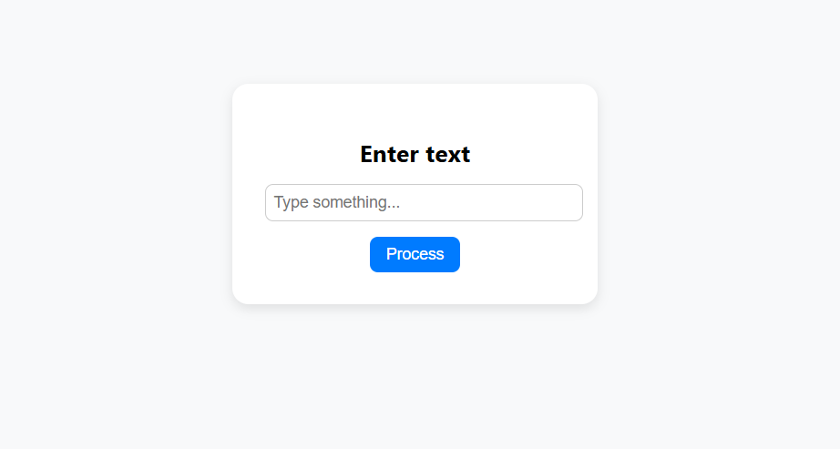

   UI of the loud-text app.

3. Type something you would like to share with the world and then hit “Process” to check how loud the app really is.

At this point, you have functional python web app running inside your docker container. Note that for public web apps hosted through docker there are several good practices for security of the app, which we won’t cover here.

If you take a quick look at your containers, you should see at least one container running that’s using the `loud-text` image and on port `5001`. To see your containers, you can use the CLI or Docker Desktop’s graphical interface.

**CLI**

Run the `docker ps` command in a terminal to list your containers.

```bash
docker ps
```

Output similar to the following should appear.

```
CONTAINER ID   IMAGE       COMMAND           CREATED         STATUS         PORTS                      NAMES
248d3a200f16   loud-text   "python app.py"   7 minutes ago   Up 7 minutes   127.0.0.1:5001->5000/tcp   quizzical_pike
```

**Docker Desktop**

In Docker Desktop, select the **Containers** tab to see a list of your containers.

[figure not shown]

Docker Desktop with loud-text container running

## Summary

In this section, you learned the basics about creating a Dockerfile to build an image. Once you built an image, you started a container and saw the running app.

# Update the application

In part 1, you containerized a simple web app. In this part, you’ll update the application and image. You’ll also learn how to stop and remove a container.

## Update the source code

In the following steps, you’ll change the “placeholder” when you haven’t typed anything into the application yet to “Yell something…”.

1. In the `app.py` file, update line 62 to use the new empty text.

```
-       <input type="text" name="text" placeholder="Type something..." autofocus>
+       <input type="text" name="text" placeholder="Yell something..." autofocus>
```

2. Build your updated version of the image, using the `docker build` command.

```bash
docker build -t loud-text .
```

3. Start a new container using the updated code.

```bash
docker run -dp 5001:5000 loud-text
```

You probably saw an error like this:

```
docker: Error response from daemon: driver failed programming external connectivity on endpoint sweet_yonath (5ecf0c721cf409e9cf7202e19a2049bbce7cd8d904d2800a53febb5d1d8f0cc6): Bind for 0.0.0.0:5001 failed: port is already allocated.
```

The error occurred because you aren’t able to start the new container while your old container is still running. The reason is that the old container is already using the host’s port 5001 and only one process on the machine (containers included) can listen to a specific port. To fix this, you need to remove the old container.

## Remove the old container

To remove a container, you first need to stop it. Once it has stopped, you can remove it. You can remove the old container using the CLI or Docker Desktop’s graphical interface. Choose the option that you’re most comfortable with.

**CLI**

#### Remove a container using the CLI

1. Get the ID of the container by using the `docker ps` command.

```bash
docker ps
```

2. Use the `docker stop` command to stop the container. Replace `<the-container-id>` with the ID from `docker ps`.

```bash
docker stop <the-container-id>
```

3. Once the container has stopped, you can remove it by using the `docker rm` command.

```bash
docker rm <the-container-id>
```

> **Note:**  
> You can stop and remove a container in a single command by adding the `force` flag to the `docker rm` command. For example:  
> `docker rm -f <the-container-id>`

**Docker Desktop**

#### Remove a container using Docker Desktop

1. Open Docker Desktop to the **Containers** view.
2. Select the trash can icon under the **Actions** column for the container that you want to delete.
3. In the confirmation dialog, select **Delete forever**.

### Start the updated app container

1. Now, start your updated app using the `docker run` command.

```bash
docker run -dp 127.0.0.1:5001:5000 loud-text
```

2. Refresh your browser on http://localhost:5001 and you should see your updated placeholder text.

## Summary

In this section, you learned how to update and rebuild an image, as well as how to stop and remove a container.

## Next steps

Next, you’re going to learn how to mount your local directory to the docker container and how to set environment variables. By using these features, you will decode an encrypted message.